# Introductions

Neil Lund

## Are you in the right room?

This is GVPT 628: Coding for Political Analysis

Instructor Info:

- Neil Lund (nlund@umd.edu)
- Office 1140C Tydings Hall (in the suite behind the glass doors)
- Office Hours: Tu: 3:30 - 5:00, Thu: 11:00 - 12:30, MWF: by appointment

## Materials

- Access to computer with Python and R-Studio
- Other materials provided through ELMS or Github

## Course Goals

By the end of the semester you should:

- Have a basic understanding of R (as well as some basic Python)
- Understand how to get from messy real world data to “clean” analyses
- Have some materials you can start using to build a portfolio

Most importantly: you should have a solid baseline to develop new skills on your own and collaborate with others.

## Rough outline of the course

Pt 1: Basics

- Loops and functions
- Munging, aggregation, visualization
- Survey analysis

Pt 2: Data collection, cleaning and project management

- Automation and replication
- Using APIs
- Building/using a relational database, basic SQL

Pt 3: Analysis, Machine learning, Prediction

- Dimensionality reduction
- Inference, prediction, and model comparison
- Working with text data

## Grades

Homework and group assignment (60%)

- More or less one a week. Submit on ELMS before class
- Must include answers AND code (that works)
- Will drop the lowest (if needed)

Participation and engagement (10%)

- Not an attendance grade!

Final Project (30%)

- Short analysis of a political science data set. Presented in last week of class. Memo due on final exam date.

## General Guidelines for assignments

- Your code should run with little-to-no modification from the person attempting to run it. Replicability is key.
- I’ll generally leave some notes to highlight issues. “See me” typically sounds more ominous than it is.
- Sometimes, we’ll do things the “hard way” just to illustrate how stuff works.

## General Guidelines for assignments

## AI Policy

In general, don’t.

AI generated search results are one minor exception. These are unavoidable, but they’re also fairly limited in what they tell you.

[figure not shown]

pictured: me, right now

## Set-up

1. Creating an R project
2. Turning off some settings
3. Connecting to a Github repository
4. Installing packages (if needed)

## Some context: parties, families and cleavages

Lipset and Rokkan: parties form around cleavages, and conflicts are “frozen” based on when democratization occurs

- conflict between landed (rural) interests and industrial (urban) interests
- conflict between owners and workers
- conflict between mainstream culture and ethno-linguistic minorities
- conflict between secular authority and churches

## Context: Party Families and European Integration

- “Party Families” emerge around cleavages, and act as vehicles for their interests (i.e. socialist parties address class cleavage, agrarian parties represent rural interests etc.)
  - note: this is a multi-dimensional view of party positions!
- But what do they do with new issues that don’t have a basis in a deep cleavage? (such as EU integration)
- Are parties really “frozen”?

## Methodology

- Primary goal: measure party positioning (initially on the EU, but subsequently across a broad range of issues)
- Secondary goal: evaluating expert consensus as a measurement

## Methodology

Examples of other quantitative methods for measuring party positions include:

- Scaling roll-call votes ([NOMINATE](https://voteview.com/about))
- Analysis of manifestos ([Comparative Manifestos Project](https://manifesto-project.wzb.eu/))
- Voter surveys of party positioning ([European Election Survey](https://www.gesis.org/en/services/finding-and-accessing-data/international-survey-programs/european-election-studies)) and elite self-placement ([EUandI](https://euandi.eu/en/data-research.html))

## Survey Instrument and measurement

[figure not shown]

1999 Expert Survey on National Parties and the European Union

- Party-Year level data (one row per party per wave) with the average position, salience, amount of dissent and “blur”
- Expert-Party-Year data (one row per expert-party-wave) with the same metrics

## Variance

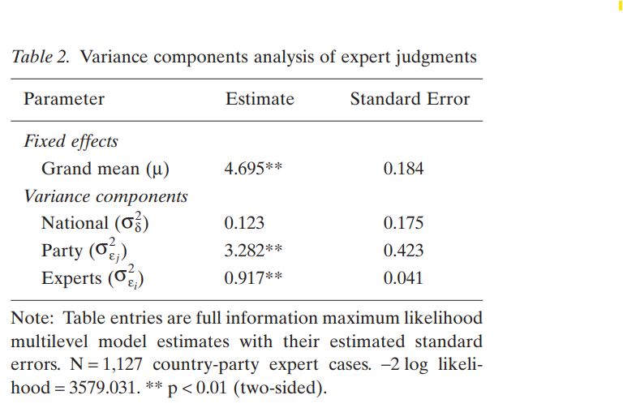

Steenbergen, Marco R., and Gary Marks. “Evaluating expert judgments.” European Journal of Political Research 46.3 (2007): 347-366.

- Experts contribute a significant but substantively small amount of variation to party placement
  - In other words: experts disagree, but not so much that we would conclude that they lack a shared understanding of party positions.

## Some Trends: EU Positions

- Traditional party families held stable positions on the EU by the 90s
- “New” families (Rad. Right and Greens) developed more cohesive positions over time

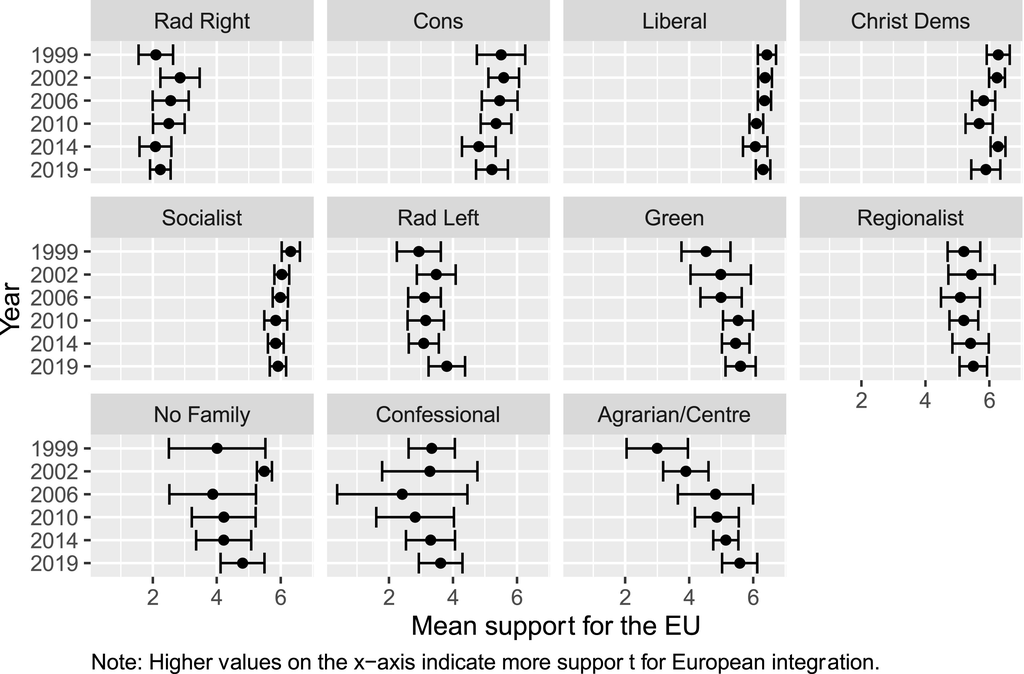

Jolly, S., Bakker, R., Hooghe, L., Marks, G., Polk, J., Rovny, J. & Vachudova, M. A. (2022). Chapel Hill expert survey trend file, 1999–2019. Electoral studies, 75, 102420.

## Some Trends: EU positions and immigration

- Immigration issues, rather than left/right positions, have become the strongest correlate of EU position taking

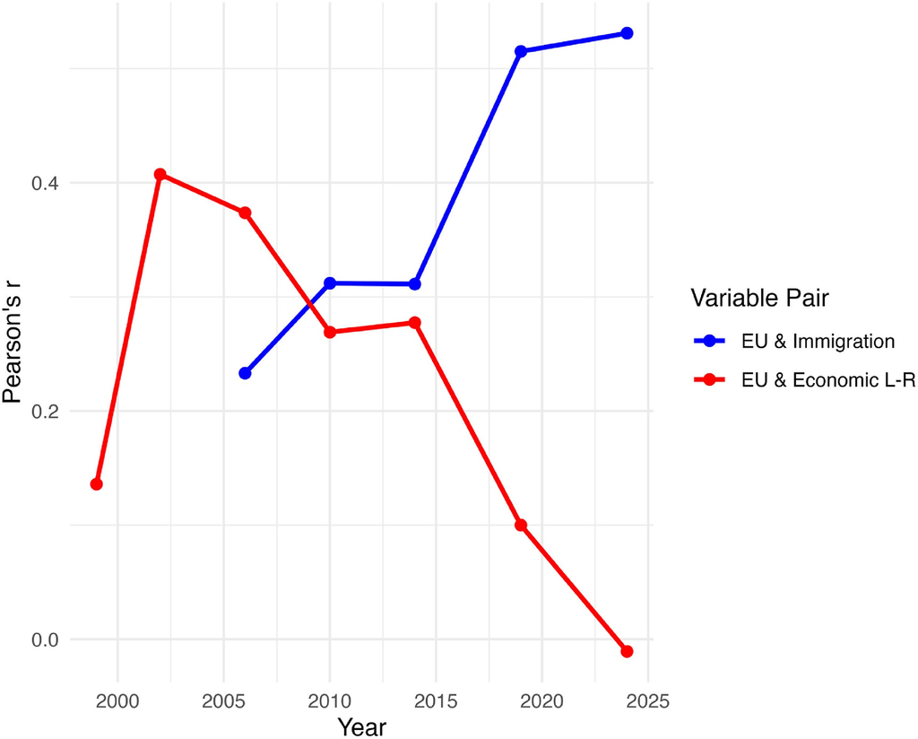

Rovny, J., Polk, J., Bakker, R., Hooghe, L., Jolly, S., Marks, G., … & Vachudova, M. A. (2025). The 2024 Chapel Hill Expert Survey on political party positioning in Europe: Twenty-five years of party positional data. Electoral Studies, 97, 102981.

## Some Trends: the GAL-TAN Dimension

- The “GAL-TAN” dimension has emerged as a new political cleavage that structures party positioning

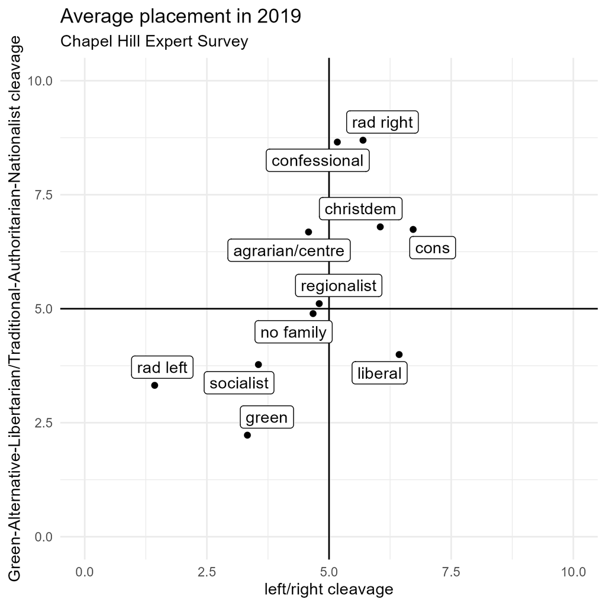

2019 Party Family Positioning on Major Issues

## Effective Number of Parties

(note: this isn’t really related to the CHES per se, but it’s relevant for studying political parties in general)

- Are there really any true “two-party” systems? How should we count the number of parties in a given country?
- The simplest method, just counting the number of parties on the ballot or in the legislature might not make much sense! (quick: how many parties were on the 2024 presidential ballot? How many mattered?)

## Effective Number of Parties

- [Laakso and Taagapera (1979)](https://escholarship.org/uc/item/703827nv): weight parties by their vote share (electoral parties or ENEP) or seat share (parliamentary parties or ENEP)

  $$\text{ENP} = \frac{1}{\sum_{i=1}^{n}p_i^2}$$

(N is the Effective Number. P is the vote/seat share)

## Effective Number of Parties

In R: if `x` is a vector of party seat shares:

50/50 split:

```r
x <- c(.5,.5)

1 / sum(x^2)
```

```
[1] 2
```

## Effective Number of Parties

Two major parties and one small one:

```r
x <- c(.5,.4, .1)

1 / sum(x^2)
```

```
[1] 2.380952
```

The UK in 2024:

```r
seats<-c(398, 120, 72, 15, 9, 6, 5, 4, 4, 4, 2,  7 , 1, 1, 1, 1)

seat_shares<- seats/sum(seats)

1/ sum(seat_shares^2)
```

```
[1] 2.367477
```

## Effective Number of Parties: notes and caveats

- The CHES data excludes some small parties, ENPP will be slightly deflated from the “real” answer
- For ease of comparison, most data sources (including CHES) only look at the lower house in bicameral systems

## In-Class

We’ll use the latest round of the Chapel Hill Expert Survey

Click here for the in-class assignment